# How many Friday 13ths?

## [Riddler Express](https://fivethirtyeight.com/features/can-you-pass-the-cranberry-sauce/)

First, an unlucky puzzle that comes a week late:

Depending on the year, there can be one, two or three Friday the 13ths. Last week happened to be the second Friday the 13th of 2020.

What is the *greatest* number of Friday the 13ths that can occur over the course of four consecutive calendar years?

*Extra credit*: What’s the greatest number of Friday the 13ths that can occur over a four-year period (i.e., a period that doesn’t necessarily begin on January 1)?

## Solution

Accounting for 7 days a week, years, leap years, and [century leap years](https://en.wikipedia.org/wiki/Century_leap_year), I decided to use a 2800 year cycle from 1000 to 3800.

```python
import calendar
from datetime import date
from datetime import datetime
from datetime import timedelta
import matplotlib.pyplot as plt
import pandas as pd
```

```python
#List of all January 1st between 1000 and 3804.
jan_firsts = []
for y in range(1000, 3805):
    temp = datetime(y, 1, 1).date()
    jan_firsts.append(temp)

#List of all Friday 13ths between 1000 and 3804.
friday_13ths = []
for y in range(1000, 3805) :
    for m in range(1,13) :
        day = datetime(y, m, 13).date()
        if calendar.day_name[day.weekday()] == "Friday" :
            friday_13ths.append(day)
```

```python
#Count the total number of Friday the 13ths in a four year span,
#starting with the date from a list.
def count_fri_thirteenths(date_list) :
    fridays_list = []
    for d in date_list:
        #Four years later is normally going to change every year by adding four, and one day subtracted from that.
        try :
            four_years_later = datetime(d.year + 4, d.month, d.day).date() - timedelta(days = 1)
        #Century years not divisible by 400 are not leap years.  Got to February 28th.
        except :
            four_years_later = datetime(d.year + 4, d.month, d.day - 1).date()

        #Create a count of Friday the 13ths in the four year span.
        fridays_count = 0
        for f in friday_13ths:
            if (d <= f) and (f <= four_years_later):
                fridays_count += 1
        fridays_list.append(fridays_count)

    #Dataframe
    df = pd.DataFrame(data = {'Date': date_list,
                              'Friday_13th_Count': fridays_list})

    return(df)

#Graph Helper.
def plotter(df, xlabel):
    fig, ax = plt.subplots(1, 1, figsize = (14, 7))

    ax.plot_date(df['Date'], df['Friday_13th_Count'], 'go', markersize = 5)
    ax.xaxis_date()
    ax.set_title("Number of Friday 13ths in the Next Four Years", fontsize = 24)
    ax.set_xlabel(xlabel = xlabel, fontsize = 18)
    plt.setp(ax.get_xticklabels(), ha = "right", rotation = 45)

    ax.set_ylabel(ylabel = "Count of Friday 13ths", fontsize = 18)
    ax.set_yticks([6, 7, 8, 9])
    ax.tick_params(axis = 'both', labelsize = 14)
```

### Four Consecutive Years

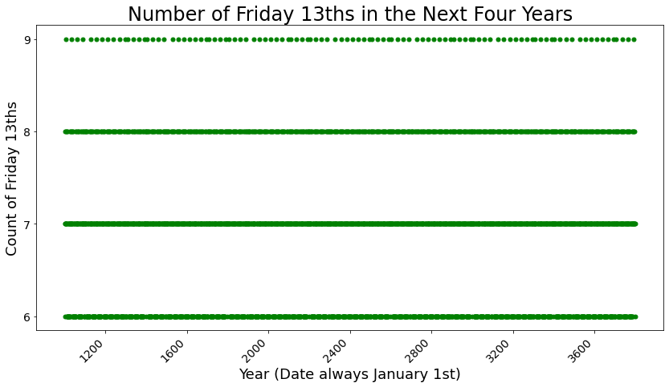

```python
df_jan_firsts = count_fri_thirteenths(jan_firsts[0:2801])
plotter(df_jan_firsts,
        "Year (Date always January 1st)")
```

### Four-Year Periods

Any maximum number of Friday 13ths in a four-year period is not limited to, but could start with a Friday 13th.

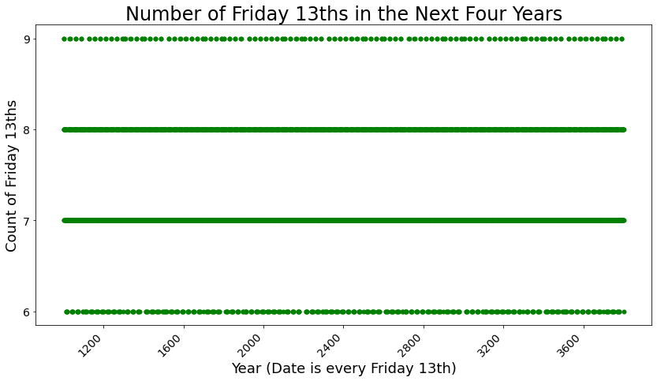

```python
df_fri_thirteenths = count_fri_thirteenths(friday_13ths[0:4820])
plotter(df_fri_thirteenths,
        "Year (Date is every Friday 13th)")
```

## Answer

The maximum, in either case, is nine Friday 13ths in four consecutive years or a four year span.

#### 2020.11.23